# Associations Between Prior Alcohol Abuse, Smoking and Depression

- Show All Code
- Hide All Code
- View Source

Using Data on 1916 Adults in NHANES 2021-2023

Author

Lauren Sapienza

Modified

2025-12-10

# 1 Setup and Data Ingest

```r
library(janitor)
library(naniar)
library(xfun)
library(knitr)
library(patchwork)
library(nhanesA)
library(gt)
library(naniar)
library(MKinfer)

library(easystats)
library(tidyverse)
source("data/Love-431.R")

theme_set(theme_bw())
knitr::opts_chunk$set(comment = NA)
```

```r
# demo_raw <- nhanes('DEMO_L') |> tibble()
# saveRDS(demo_raw, "DEMO_L.Rds")

# depr_raw <- nhanes('DPQ_L') |> tibble()
# saveRDS(depr_raw, "DPQ_L.Rds")

# smoke_raw <- nhanes('SMQ_L') |> tibble()
# saveRDS(smoke_raw, "SMQ_L.Rds")

# alc_raw <- nhanes('ALQ_L') |> tibble()
# saveRDS(alc_raw, "ALQ_L.Rds")

# bmi_raw <- nhanes('BMX_L') |> tibble()
# saveRDS(bmi_raw, "BMX_L.Rds")
```

Here we load in all our different data files using the `nhanesA` package, and save them as .Rds files, then comment the code out so we do not have to reload the data each time we run the code.

# 2 Cleaning the Data

## 2.1 Variable Cleaning and Renaming

```r
demo_raw <- readRDS('data/DEMO_L.Rds')

demo_raw <- demo_raw |> mutate(check = factor(RIDSTATR),
                                age = RIDAGEYR) |> select(SEQN, age, check)
```

For the demographics data, we rename some of the variables for clarity, change the necessary variables into factors, and select only the variables we need.

```r
depr_raw <- readRDS('data/DPQ_L.Rds')

depr_raw <- depr_raw |> mutate(depr = factor(DPQ020)) |> select(SEQN, depr) |>
  replace_with_na_at(.vars = 'depr', condition = ~ .x == 'Refused') |>
  replace_with_na_at(.vars = 'depr', condition = ~ .x == "Don't know")
```

For the depression questionnaire data, we select our variable of interest, rename it for clarity, change it into a factor, and change all missing answers into NA values.

```r
smoke_raw <- readRDS('data/SMQ_L.Rds')

smoke_raw <- smoke_raw |>
  mutate(smoke = case_when(SMQ040 == 'Every day' | SMQ040 == 'Some days' ~ "Smoker",
                           SMQ040 == 'Not at all' ~ "Non-Smoker")) |>
  mutate(smoke = factor(smoke)) |> select(SEQN, smoke)
```

For the smoking questionnaire data, we select our variable of interest, rename it for clarity, and change it into a factor. We also collapse the answers of ‘every day’ and ‘some days’ into a category called smoker.

```r
alc_raw <- readRDS('data/ALQ_L.Rds')

alc_raw <- alc_raw |> mutate(alcohol = factor(ALQ151)) |> select(SEQN, alcohol)|>
  replace_with_na_at(.vars = 'alcohol', condition = ~ .x == 'Refused') |>
  replace_with_na_at(.vars = 'alcohol', condition = ~ .x == "Don't know")
```

For the alcohol questionnaire data, we select our variable of interest, rename it for clarity, change it into a factor, and change all missing answers into NA values.

```r
bmi_raw <- readRDS('data/BMX_L.Rds')

bmi_raw <- bmi_raw |> mutate(bmi = BMXBMI) |> select(SEQN, bmi)
```

For the BMI examination data, we select our variable of interest and rename it for clarity.

## 2.2 Joining the Data

```r
NEW <- left_join(demo_raw, depr_raw, by = "SEQN")
NEW2 <- left_join(NEW, alc_raw, by = "SEQN")
NEW3 <- left_join(NEW2, smoke_raw, by = "SEQN")
study1_raw <- left_join(NEW3, bmi_raw, by = "SEQN")

study1_raw <- study1_raw |>
  filter(age < 80 & age >= 21 & check == 'Both interviewed and MEC examined') |>
  mutate(seqn = as.character(SEQN)) |>
  select(seqn, age, depr, alcohol, smoke, bmi, check) |>
  droplevels()
```

We then join all of our tibbles by `SEQN`, and filter our data to only adults between 21 and 79 that were both interviewed and MEC examined. We also change `seqn` into a character variable and reorder the columns of our tibble.

## 2.3 Missing Data

```r
miss_var_summary(study1_raw)
```

```
# A tibble: 7 × 3
  variable n_miss pct_miss
  <chr>     <int>    <num>
1 smoke      3329    58.7
2 alcohol    1154    20.4
3 depr        710    12.5
4 bmi          77     1.36
5 seqn          0     0
6 age           0     0
7 check         0     0
```

```r
miss_case_table(study1_raw)
```

```
# A tibble: 5 × 3
  n_miss_in_case n_cases pct_cases
           <int>   <int>     <dbl>
1              0    1916    33.8
2              1    2691    47.5
3              2     632    11.1
4              3     405     7.14
5              4      25     0.441
```

```r
mcar_test(study1_raw |> select(depr, alcohol, smoke, bmi))
```

```
# A tibble: 1 × 4
  statistic    df p.value missing.patterns
      <dbl> <dbl>   <dbl>            <int>
1      408.    25       0               14
```

We are missing quite a bit of data, with only 33.8% of cases having complete data. As expected, however, all subjects have data for `seqn`, `age`, and `check` since we used these variables to filter the data. The `mcar_test` function does not seem to imply that the data are missing completely at random, but we will still filter to only complete cases for all our variables.

```r
study1_raw <- study1_raw  |>
  filter(complete.cases(seqn, age, depr, alcohol, smoke, bmi, check))

# saveRDS(study1_raw, "study1.Rds")

study1 <- readRDS("data/study1.Rds")

summary(study1)
```

```
     seqn                age                             depr      alcohol
 Length:1916        Min.   :21.00   Not at all             :1181   Yes: 608
 Class :character   1st Qu.:43.00   Several days           : 527   No :1308
 Mode  :character   Median :59.00   More than half the days: 119
                    Mean   :55.49   Nearly every day       :  89
                    3rd Qu.:68.00
                    Max.   :79.00
        smoke           bmi                                      check
 Non-Smoker:1209   Min.   :15.20   Both interviewed and MEC examined:1916
 Smoker    : 707   1st Qu.:25.10
                   Median :28.90
                   Mean   :30.02
                   3rd Qu.:33.80
                   Max.   :68.50
```

For study 1, we are assuming our data are missing completely at random and so we filter to complete cases of all our variables. A quick summary of the data shows us that all our variables look as expected, with no missing values, and shows us our final data set contains 1916 subjects.

# 3 Codebook and Data Description

Our final data set contains 1916 adults that participated in NHANES 2021-2023 between ages 21 and 79 who have complete data on all 7 variables listed in the code book and were both interviewed and MEC examined.

## 3.1 Codebook

| Variable | Type | Description | Old Name |
| --- | --- | --- | --- |
| **seqn** | ID | Respondent sequence number | `SEQN` |
| **age** | ID | Age in years at screening, should be between 21 and 79 | `RIDAGEYR` |
| **depr** | 4-Cat | Not at all, Several days, More than half the days, Nearly every day: Over the last 2 weeks, how often have you been bothered by the following problem: feeling down, depressed, or hopeless? | `DPQ020` |
| **alcohol** | Binary | Yes, No: Was there ever a time or times in your life when you drank 4/5 or more drinks of any kind of alcoholic beverage almost every day? | `ALQ151` |
| **smoke** | Binary | Smoker, Non-Smoker: Do you now smoke cigarettes? | `SMQ040` |
| **bmi** | Quant | Body Mass Index (kg/m<sup>2</sup>) | `BMXBMI` |
| **check** | check | Interview and examination status of the participant, should be ‘both interviewed and MEC examined’ for all subjects | `RIDSTATR` |

## 3.2 Analytic Tibble

```r
study1
```

```
# A tibble: 1,916 × 7
   seqn     age depr                    alcohol smoke        bmi check
   <chr>  <dbl> <fct>                   <fct>   <fct>      <dbl> <fct>
 1 130379    66 Not at all              No      Non-Smoker  33.5 Both interview…
 2 130386    34 Not at all              No      Non-Smoker  30.2 Both interview…
 3 130389    59 Not at all              No      Non-Smoker  28   Both interview…
 4 130396    56 Several days            No      Non-Smoker  27.3 Both interview…
 5 130406    26 Not at all              No      Smoker      25.1 Both interview…
 6 130407    73 Not at all              No      Non-Smoker  28.1 Both interview…
 7 130426    67 More than half the days No      Smoker      27.2 Both interview…
 8 130437    43 Several days            No      Non-Smoker  37   Both interview…
 9 130449    26 Several days            No      Non-Smoker  34.6 Both interview…
10 130450    54 Not at all              Yes     Non-Smoker  36.3 Both interview…
# ℹ 1,906 more rows
```

## 3.3 Data Summary

```r
describe_distribution(study1)
```

```
Variable |  Mean |    SD |   IQR |          Range | Skewness | Kurtosis |    n | n_Missing
------------------------------------------------------------------------------------------
age      | 55.49 | 14.94 | 25.00 | [21.00, 79.00] |    -0.48 |    -0.87 | 1916 |         0
bmi      | 30.02 |  7.13 |  8.70 | [15.20, 68.50] |     1.08 |     2.05 | 1916 |         0
```

```r
data_codebook(study1 |> select(-seqn))
```

```
select(study1, -seqn) (1916 rows and 6 variables, 6 shown)

ID | Name    | Type        | Missings |                            Values |             N
---+---------+-------------+----------+-----------------------------------+--------------
1  | age     | numeric     | 0 (0.0%) |                          [21, 79] |          1916
---+---------+-------------+----------+-----------------------------------+--------------
2  | depr    | categorical | 0 (0.0%) |                        Not at all | 1181 ( 61.6%)
   |         |             |          |                      Several days |  527 ( 27.5%)
   |         |             |          |           More than half the days |  119 (  6.2%)
   |         |             |          |                  Nearly every day |   89 (  4.6%)
---+---------+-------------+----------+-----------------------------------+--------------
3  | alcohol | categorical | 0 (0.0%) |                               Yes |  608 ( 31.7%)
   |         |             |          |                                No | 1308 ( 68.3%)
---+---------+-------------+----------+-----------------------------------+--------------
4  | smoke   | categorical | 0 (0.0%) |                        Non-Smoker | 1209 ( 63.1%)
   |         |             |          |                            Smoker |  707 ( 36.9%)
---+---------+-------------+----------+-----------------------------------+--------------
5  | bmi     | numeric     | 0 (0.0%) |                      [15.2, 68.5] |          1916
---+---------+-------------+----------+-----------------------------------+--------------
6  | check   | categorical | 0 (0.0%) | Both interviewed and MEC examined | 1916 (100.0%)
-----------------------------------------------------------------------------------------
```

All our variables appear as expected, with reasonable ranges of values and no missing values.

# 4 Analysis B: Comparing 2 Means with Independent Samples

## 4.1 Question

For analysis B I decided to look at the relationship between being a current smoker and BMI. There is no reason to pair these groups, and they contain a different number of subjects, so we will compare the mean of the smoker group to the mean of the nonsmoker group and see how much of a difference there is between them. My research question is:

What is the difference between the mean BMI of smokers and the mean BMI of nonsmokers in NHANES 2021-2023?

## 4.2 Describing the Data

We are looking at two variables for analysis B: `smoke` and `bmi`. `smoke` represents the subjects smoker status and has two options, smoker and nonsmoker. `bmi` is the participants body mass index and is measured in kg/m<sup>2</sup>.

### 4.2.1 Graphical Summaries

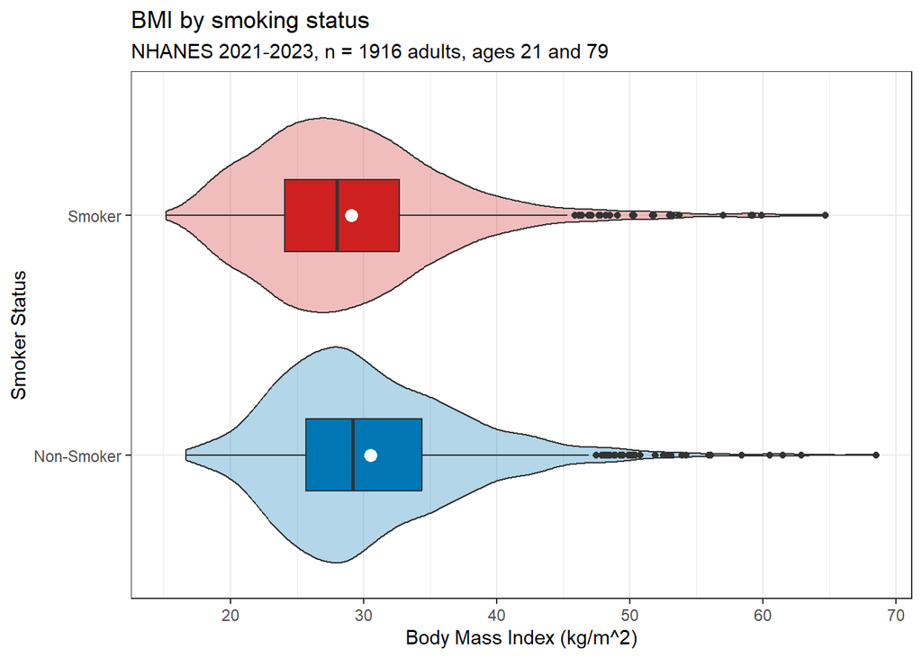

```r
ggplot(study1, aes(y = smoke, x = bmi, fill = smoke)) +
  geom_violin(alpha = 0.3) +
  geom_boxplot(width = 0.3) +
  stat_summary(fun = mean, geom = "point", size = 3, col = "white") +
  scale_fill_social() +
  guides(fill = "none") +
  labs(title = "BMI by smoking status",
       subtitle = "NHANES 2021-2023, n = 1916 adults, ages 21 and 79",
       y = "Smoker Status", x = "Body Mass Index (kg/m^2)")
```

Looking at the distribution of BMI by smoker status we see that both groups have some significant right skew. It also looks like from a first glance that there is not much difference between the means of each group, but we still want to see what the magnitude of the difference is. However, based on the amount of skew, we might want to avoid tests that assume normality.

### 4.2.2 Numerical Summaries

```r
study1 |> group_by(smoke) |> reframe(lovedist(bmi)) |>
  gt() |> fmt_number(decimals = 2, drop_trailing_zeros = TRUE)
```

| smoke | n | miss | mean | sd | med | mad | min | q25 | q75 | max |
| --- | --- | --- | --- | --- | --- | --- | --- | --- | --- | --- |
| Non-Smoker | 1,209 | 0 | 30.56 | 7.01 | 29.2 | 6.23 | 16.7 | 25.7 | 34.4 | 68.5 |
| Smoker | 707 | 0 | 29.11 | 7.25 | 28 | 6.23 | 15.2 | 24.1 | 32.7 | 64.7 |

First, we see that we have over 30 observations in each group. We also see that there is less than 2 point difference in the BMIs of the two groups. The variance is also similar between groups. In the non-smoker group, the sample mean BMI is 30.56 and sample median BMI is 29.2, while the sample standard deviation of BMI is 7.01. So the mean is 19.4% of a standard deviation above the median. In the smoker group, the sample mean BMI is 29.11 and sample median BMI is 28, while the sample standard deviation of BMI is 7.25. So the mean is 15.3% of a standard deviation above the median. Since around 20% of a standard deviation is a good cut off for meaningful right skew, it looks like we should still be cautious about assuming normality.

```r
study1 |> select(bmi) |> n_distinct()
```

```
[1] 329
```

We also check to make sure our quantitative variable, BMI, has over 15 unique values, which it does.

## 4.3 Analysis

```r
fitB1 <- lm(bmi ~ smoke, data = study1)

model_parameters(fitB1, ci = 0.90)
```

```
Parameter      | Coefficient |   SE |         90% CI | t(1914) |      p
-----------------------------------------------------------------------
(Intercept)    |       30.56 | 0.20 | [30.22, 30.89] |  149.70 | < .001
smoke [Smoker] |       -1.45 | 0.34 | [-2.00, -0.89] |   -4.31 | < .001
```

```
Uncertainty intervals (equal-tailed) and p-values (two-tailed) computed
  using a Wald t-distribution approximation.
```

```r
set.seed(431)

boot.t.test(bmi ~ smoke, var.equal = TRUE, R = 2000,
  data = study1, conf.level = 0.90)
```

```
    Bootstrap Two Sample t-test

data:  bmi by smoke
number of bootstrap samples:  2000
bootstrap p-value < 5e-04
bootstrap difference of means (SE) = 1.441185 (0.3373966)
90 percent bootstrap percentile confidence interval:
 0.8665332 2.0002463

Results without bootstrap:
t = 4.3054, df = 1914, p-value = 1.751e-05
alternative hypothesis: true difference in means is not equal to 0
90 percent confidence interval:
 0.8937216 1.9996493
sample estimates:
mean in group Non-Smoker     mean in group Smoker
                30.55616                 29.10948
```

I ran both a pooled t test and a bootstrap here, mostly to see if there was much of a difference at all between the methods. While we are on the edge of having meaningful right skew, we do have fairly equal variances and large sample sizes, so I thought I would try the pooled t to see how it compared to a bootstrap, which I believe to be the most appropriate model. In the end, there was little difference, so either would probably be appropriate, but I will go with the bootstrap. The population mean BMI in non-smokers is estimated to be about 1.44 kg/m<sup>2</sup> higher than the population mean BMI for smokers, based on our samples. So the mean differences’ point estimate is 1.44. Our 90% bootstrapped confidence interval for the difference (Non-Smoker - Smoker) of the population means is (0.87, 2.00). This means when we generalize beyond study participants to the population they were selected at random from, then our data are compatible (at the 90% confidence level) with differences between the two population means between 0.87 and 2.00, depending on the assumptions of our bootstrap estimation procedure being correct. The assumptions of this bootstrap procedure are that the samples in each group are drawn independently of each other and that the samples in each group represent a random sample of the population of interest.

## 4.4 Conclusions

The point estimate of the difference between the population mean BMI for non-smokers minus the population mean BMI for smokers is 1.44, with a 90% confidence interval of (0.87, 2.00), based on our sample. This conclusion is motivated by a bootstrap estimate to compare the two groups, which I believe is the most justified approach based on the apparent skew in the data.

While this is an answer to our research question, these results do not seem very clinically significant. Looking at a BMI chart, the difference between a BMI of 29 and 30, the approximate population mean of smokers and non-smokers respectively, would only be around 10 pounds of weight difference or 1 inch height difference. Further investigation could make sure there are not any factors confounding the results, to make sure there really is no important association between smoking status and BMI. For example, age could be a confounder, as older people might be more or less likely to smoke while BMI might change with age due to changes in muscle and body fat percentages. I would research some variables that could be confounders and see if my results continue to hold up.

# 5 Analysis C: Comparing 4 Means with Independent Samples

## 5.1 Question

For analysis C I decided to look at the relationship a depression screening question and BMI. To do this I will perform an analysis of variance to compare the mean BMI between four different groups. There are no links between the groups and they all contain different amounts of subjects, so we will analyse them as independent samples. My research question is:

Is there a meaningful difference between the mean BMI of NHANES 2021-2023 participants who answered not at all, several days, more than half the days, and nearly every day to the depression screening question “feeling down, depressed, or hopeless”?

## 5.2 Describing the Data

We are looking at two variables for analysis C: `depr` and `bmi`. `depr` represents the subjects answer to the question, “Over the last 2 weeks, how often have you been bothered by the following problem: feeling down, depressed, or hopeless?” `depr` has four answers: Not at all, several days, more than half the days, and nearly every day. `bmi` is the participants body mass index and is measured in kg/m<sup>2</sup>.

### 5.2.1 Graphical Summaries

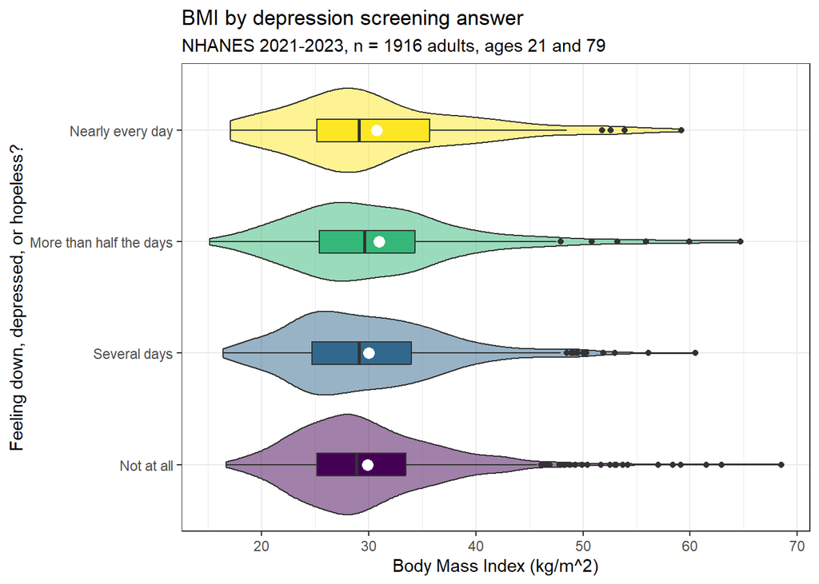

```r
ggplot(study1, aes(x = depr, y = bmi, fill = depr)) +
  geom_violin(alpha = 0.5) +
  geom_boxplot(width = 0.2) +
  stat_summary(fun = "mean", geom = "point", size = 3, col = "white") +
  coord_flip() +
  scale_fill_viridis_d() +
  guides(fill = "none") +
  labs(title = "BMI by depression screening answer",
       y = "Body Mass Index (kg/m^2)",
       x = "Feeling down, depressed, or hopeless?",
       subtitle = 'NHANES 2021-2023, n = 1916 adults, ages 21 and 79')
```

It looks like we have a good amount of right skew in all of our distributions, but otherwise the distribution looks pretty similar between groups. All of the means and medians seem very similar between groups, so I don’t know if there will be any important differences between groups just looking at this. From this, it looks like we might want to avoid test that assume normality.

### 5.2.2 Numerical Summaries

```r
study1 |> group_by(depr) |> reframe(lovedist(bmi)) |>
  gt() |> fmt_number(decimals = 2, drop_trailing_zeros = TRUE)
```

| depr | n | miss | mean | sd | med | mad | min | q25 | q75 | max |
| --- | --- | --- | --- | --- | --- | --- | --- | --- | --- | --- |
| Not at all | 1,181 | 0 | 29.88 | 6.79 | 28.9 | 5.93 | 16.7 | 25.2 | 33.5 | 68.5 |
| Several days | 527 | 0 | 30.01 | 7.2 | 29.1 | 6.97 | 16.4 | 24.7 | 34 | 60.5 |
| More than half the days | 119 | 0 | 30.96 | 8.63 | 29.6 | 6.82 | 15.2 | 25.4 | 34.35 | 64.7 |
| Nearly every day | 89 | 0 | 30.73 | 8.69 | 29.1 | 6.67 | 17.1 | 25.2 | 35.7 | 59.2 |

First, we see that we have over 30 observations in each group, and we already know from analysis B that our quantitative variable, BMI, has over 15 unique values. We also see here how close the means and medians are to each other between each group, with a maximum difference of less than 2 points. Checking our right skew, there is a 14.4% of a standard deviation difference between the mean and median of the ‘not at all’ group, 12.6% of a standard deviation difference between ‘several days’ group, 15.8% of a standard deviation difference between ‘more than half the days’ group, and 18.8% of a standard deviation difference between ‘nearly every day’ group. It looks like we might be okay to assume normality despite the right skew, but we should be cautious.

## 5.3 Analysis

```r
fitC <- lm(bmi ~ depr, data = study1)

fitC |> anova()
```

```
Analysis of Variance Table

Response: bmi
            Df Sum Sq Mean Sq F value Pr(>F)
depr         3    174  58.078  1.1428 0.3304
Residuals 1912  97167  50.820
```

```r
fitC |> eta_squared()
```

```
For one-way between subjects designs, partial eta squared is equivalent
  to eta squared. Returning eta squared.
```

```
# Effect Size for ANOVA

Parameter |     Eta2 |       95% CI
-----------------------------------
depr      | 1.79e-03 | [0.00, 1.00]

- One-sided CIs: upper bound fixed at [1.00].
```

Unsurprisingly, our ANOVA results show that there seems to be little chance of meaningful differences between our groups, with only an extremely small amount of variation explained by our model. For an ANOVA test, we assume that the samples in each category are drawn independently of each other, that the samples in each category represent a random sample of the population of interest, the samples in each category are drawn from a normally distributed population, and that either the sample sizes or the population variances are equal across the categories. I feel comfortable making all these assumptions, except for normality, which I am a little more concerned about, but the effect of `depr` on `bmi` is so small and our right skew was determined to be under the meaningful amount, so I will continue to investigating the pairwise comparisons between all our variables.

```r
conC1 <- estimate_contrasts(fitC, contrast = "depr",
                           ci = 0.90, p.adjust = "holm")

conC1 |> gt() |> fmt_number(decimals = 2, drop_trailing_zeros = TRUE)
```

| Level1 | Level2 | Difference | SE | CI_low | CI_high | t | df | p |
| --- | --- | --- | --- | --- | --- | --- | --- | --- |
| Several days | Not at all | 0.14 | 0.37 | −0.48 | 0.75 | 0.36 | 1,912 | 0.72 |
| More than half the days | Not at all | 1.08 | 0.69 | −0.05 | 2.21 | 1.58 | 1,912 | 0.11 |
| Nearly every day | Not at all | 0.86 | 0.78 | −0.43 | 2.15 | 1.09 | 1,912 | 0.27 |
| More than half the days | Several days | 0.95 | 0.72 | −0.25 | 2.14 | 1.31 | 1,912 | 0.19 |
| Nearly every day | Several days | 0.72 | 0.82 | −0.62 | 2.06 | 0.88 | 1,912 | 0.38 |
| Nearly every day | More than half the days | −0.23 | 1 | −1.87 | 1.42 | −0.23 | 1,912 | 0.82 |

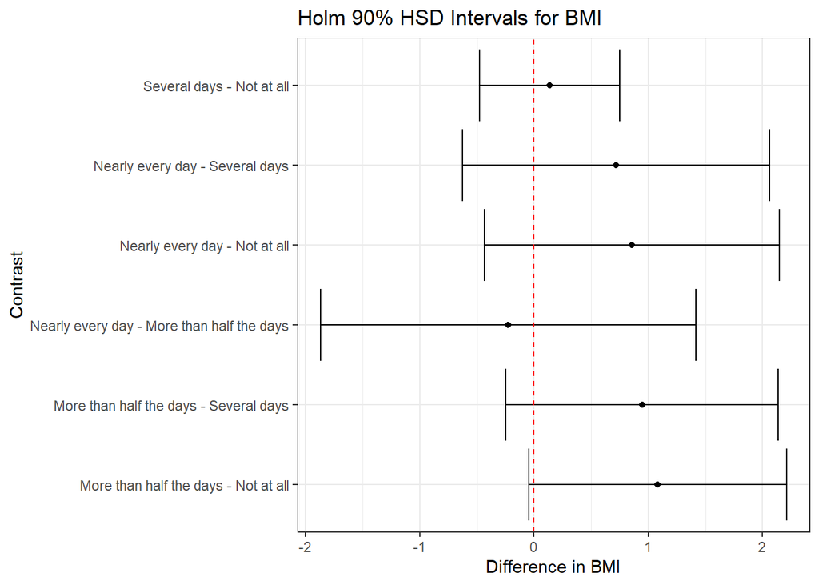

```r
conC1_tib <- tibble(conC1) |>
  mutate(contr = str_c(Level1, " - ", Level2))

ggplot(conC1_tib, aes(y = contr, x = Difference)) +
  geom_point() +
  geom_errorbar(aes(xmin = CI_low, xmax = CI_high)) +
  geom_vline(xintercept = 0, col = "red", lty = "dashed") +
  labs(title = "Holm 90% HSD Intervals for BMI",
       y = "Contrast",
       x = "Difference in BMI")
```

Looking at our Holm pairwise comparison results, we see that the largest difference between groups is only 1.08 kg/m<sup>2</sup>, and our p-values are all above 0.1, which together makes me believe that there is no meaningful difference between any of the groups. Graphing the confidence intervals, they all include 0, further demonstrating the lack of meaningful difference. For a Holm pairwise comparison, we make the same assumptions as our ANOVA, which have not changed.

## 5.4 Conclusions

Based on the results of our ANOVA and Holm pairwise comparison, I do not believe that there is a meaningful difference in the mean BMI of participants that answered not at all, several days, more than half the days, and nearly every day to the depression screening question “feeling down, depressed, or hopeless”. I believe these to be the most justified approaches, despite concerns about normality.

These results surprised me, as I believed that there would be at least a little bit of a difference between groups, but our analysis implies that any differences between groups is due to random error. Overeating or undereating, both of which could affect BMI, are symptoms of depression and a question on the PHQ-9 asks about it, so I think there could still be a link there. To investigate further, I would look at subjects diagnosed with depression and pair them with similar subjects without depression, and see if there was a stronger connection between depression and BMI could be found.

# 6 Analysis D: Analyzing a 2x2 table

## 6.1 Question

For analysis D I decided to look at the relationship between being a current smoker and a history of alcohol abuse. These are both binary variables, so we will be using a 2x2 table to investigate the relative risk of being a current smoker based on a history of alcohol abuse. My research question is:

What is the relative risk of being a current smoker based on alcohol abuse history in NHANES 2021-2023?

## 6.2 Describing the Data

We are looking at two variables for analysis D: `smoke` and `alcohol`. `smoke` represents the subjects smoker status and has two options, smoker and nonsmoker. `alcohol` represents the answer to the yes or no question: was there ever a time or times in your life when you drank 4/5 or more drinks of any kind of alcoholic beverage almost every day?

### 6.2.1 Numerical Summaries

```r
study1 |> tabyl(alcohol, smoke) |> gt()
```

| alcohol | Non-Smoker | Smoker |
| --- | --- | --- |
| Yes | 323 | 285 |
| No | 886 | 422 |

We will want to change this tibble slightly for our final analysis. First, we will flip the smoker and non-smoker variables so our top left cell has all the subjects where `alcohol` is yes and `smoke` is smoker. We can also rename the answers to the `alcohol` variable to make it clearer when looking at the table. Then, we will perform a Bayesian augmentation by adding two to each cell. Otherwise, everything looks fine here, and we see that we have over 30 observations in each group.

## 6.3 Analysis

```r
twobytwo(287, 325, 424, 888,
         "Prior Alcohol Abuse", "No Prior Alcohol Abuse", "Smoker", "Non-Smoker",
         conf.level = 0.90)
```

```
2 by 2 table analysis:
------------------------------------------------------
Outcome   : Smoker
Comparing : Prior Alcohol Abuse vs. No Prior Alcohol Abuse

                       Smoker Non-Smoker    P(Smoker) 90% conf. interval
Prior Alcohol Abuse       287        325       0.4690    0.4360   0.5022
No Prior Alcohol Abuse    424        888       0.3232    0.3023   0.3448

                                   90% conf. interval
             Relative Risk: 1.4511    1.3175   1.5982
         Sample Odds Ratio: 1.8495    1.5684   2.1809
Conditional MLE Odds Ratio: 1.8489    1.5602   2.1912
    Probability difference: 0.1458    0.1064   0.1850

             Exact P-value: 0.0000
        Asymptotic P-value: 0.0000
------------------------------------------------------
```

The relative risk of being a current smoker with a history of alcohol abuse vs. being a current smoker with no history of alcohol abuse is estimated to be 1.45, with 90% confidence interval of (1.32, 1.60). The relative risk is greater than 1, meaning that subjects with a history of alcohol abuse are more likely to be a current smoker than subjects without a history of alcohol abuse. Our confidence interval is 1.32 to 1.60, meaning that when we generalize beyond study participants to the population they were selected at random from, then our data are compatible (at the 90% confidence level) with differences between the two population means between 1.32 and 1.60, depending on the assumptions being correct. We only need to assume a large enough sample size, greater than 10 in each cell, which we easily meet.

The difference in probability of being a current smoker given prior alcohol abuse vs. no prior alcohol abuse is estimated to be 0.1458, with a 90% confidence interval of (0.1064, 0.1850). Our point estimate is greater than 0, which means that the probability of being a current smoker is higher for subjects with a history of alcohol abuse than for subjects with no history of alcohol abuse. Our confidence interval is 0.1064 to 0.1850, meaning that when we generalize beyond study participants to the population they were selected at random from, then our data are compatible (at the 90% confidence level) with differences between the two population means between 0.1064 and 0.1850, depending on the assumptions being correct. We only need to assume a large enough sample size, greater than 10 in each cell, which we easily meet.

The chi-square test of independence, assesses the null hypothesis of no association between alcohol abuse history and current smoker status, using either Fisher’s exact test or the Pearson chi-square test (labeled asymptotic here). The p value here is very small, appearing as 0, indicating that there is support for an association between alcohol abuse history and current smoker status.

## 6.4 Conclusions

The point estimate of the relative risk of being a current smoker given a history of alcohol abuse versus no history of alcohol abuse is 1.45, with 90% confidence interval of (1.32, 1.60). This conclusion is motivated by our two by two table analysis and chi-square test, which I believe to be the most justified approach considering our large sample size.

These results fall in line with what I expected to see, subjects with a history of alcohol abuse were more likely to be a current smoker than those with no history. The probability of being a current smoker given prior alcohol abuse is 46.9% while the probability of being a current smoker given no prior alcohol abuse is 32.3%, and I think this is a clinically important difference. To investigate the connection further, I would consider stratifying the results by potential confounders, such as age or other substance abuse problems, to see if there is still a large difference in probability between our groups.

# 7 Analysis E: Analyzing a 2x4 table

## 7.1 Question

For analysis E I decided to look at the relationship between a history of alcohol abuse and answers to a depression screening question. The `alcohol` variable has 2 answers and the `depr` variable has 4 answers, so we will be using a 2x4 table to analyse the relationship between them. My research question is:

What does the association between prior alcohol abuse and the answer to the depression screening question “feeling down, depressed, or hopeless” look like for NHANES 2021-2023 participants?

## 7.2 Describing the Data

We are looking at two variables for analysis E: `depr` and `alcohol`. `depr` represents the subjects answer to the question, “Over the last 2 weeks, how often have you been bothered by the following problem: feeling down, depressed, or hopeless?” `depr` has four answers: Not at all, several days, more than half the days, and nearly every day. `alcohol` represents the answer to the yes or no question: was there ever a time or times in your life when you drank 4/5 or more drinks of any kind of alcoholic beverage almost every day?

### 7.2.1 Numerical Summaries

```r
tabylE <- study1 |> tabyl(depr, alcohol) |>
  gt() |> fmt_number(decimals = 2, drop_trailing_zeros = TRUE)

tabylE
```

| depr | Yes | No |
| --- | --- | --- |
| Not at all | 312 | 869 |
| Several days | 204 | 323 |
| More than half the days | 52 | 67 |
| Nearly every day | 40 | 49 |

We should be able to easily meet the Cochran conditions here, as we have far more than 5 subjects in each cell. We also have over 10 subjects in each cell, so our chi-square test should give reasonably reliable results. We also confirm that we have over 15 observations in each group.